# SFU MATH 495: Data Science: Network Analysis Project (Part One)

Jake Robbins

November 25, 2018

## Intro

This project was completed as part of coursework for MATH 495 Fall 2018 at Simon Fraser University. The course was largely concerned with the mathematics of various machine learning and network analysis methods, with two small projects for a sense of practical application.

In this project I analyse a network dataset. The nodes in the network are doctors, and we have some information about when they first prescribed a new drug. This gives us a nice opportunity to explore this social network of doctors using network science, and to relate the network structure to the prescribing behaviour.

The vertices represent about 85% of the doctors in 4 cities. The edges are derived from answers to questions about who doctors turned to for advice, with whom they had discussions about medical practice, and with whom they socialised. Prescription records were used to obtain the month in which each doctor prescribed the new drug (if they did). The dataset also has four kinds of edges, for whether the link is based on giving advice, having a discussion, being friends, or a random link. The instructor added the random links; they are not part of the original dataset

## Exploring the Network

Our data concerns a network of doctors located in 4 cities, connected to one another by 4 types of relationships; ‘advice’,‘discussion’, ‘friend’ and ‘random’. We also have data about each individual doctor across 13 variables.

We will begin by loading and plotting the network of Doctors.

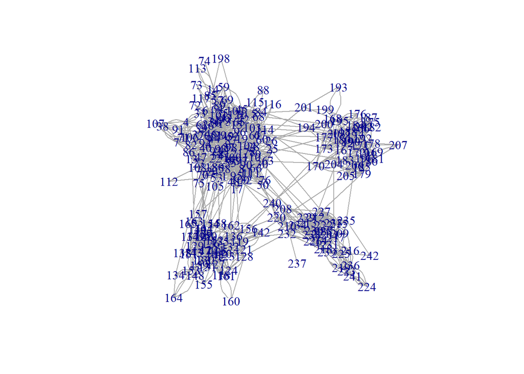

```r
load("doctornet.Rdata")

plot(docnet2,vertex.size=0.3,edge.arrow.size=0.1, vertex.color="blue", vertex.frame.color=NA,xlim=c(-.9,.9),ylim=c(-.9,.9))
```

Each vertex represents a doctor and each edge a relationship of one of the four types. We can count the number of vertices and edges:

```r
vcount(docnet2)
```

```
## [1] 242
```

```r
ecount(docnet2)
```

```
## [1] 1611
```

Many of the vertices have multiple edges. We can create a histogram of the degrees of the vertices and find the mean degree of all vertices as follows:

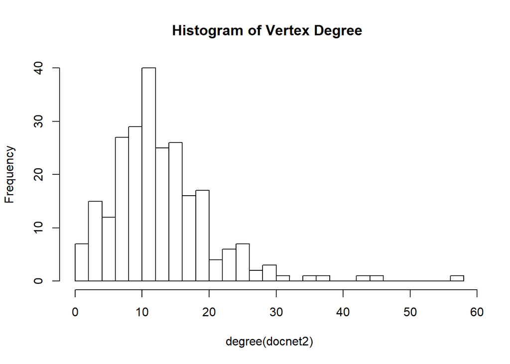

```r
hist(degree(docnet2), breaks = 30, main = "Histogram of Vertex Degree ")
```

```r
mean(degree(docnet2))
```

```
## [1] 13.31405
```

If we seperate the network by the type of connection between doctors, we are left with the four subgraphs of the different types. We can see in the following plots of these networks that for the types ‘friend’,‘discussion’, and ‘advice’, each of these networks are comprised of multiple components (whereas taken altogether as above, the Network is one single connected graph):

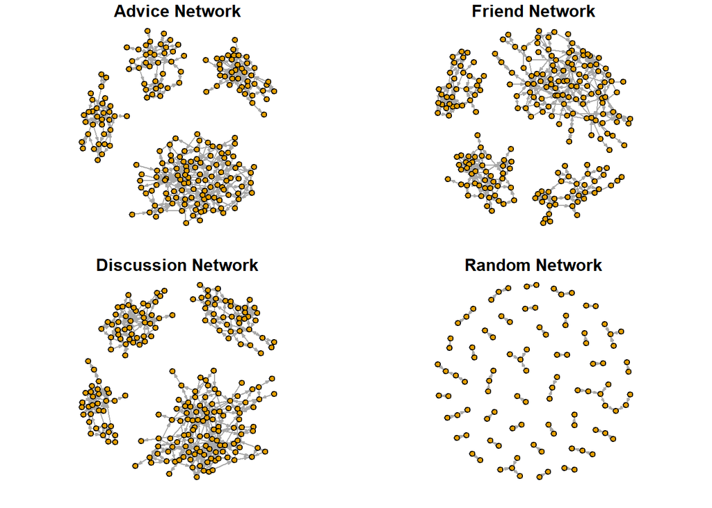

```r
par(mfrow=c(2,2),mai=c(.2,.2,.2,.2))


plot(subgraph.edges(docnet2, E(docnet2)[type=="advice"]),vertex.size=6, edge.arrow.size=.2, main="Advice Network", vertex.label=NA)
plot(subgraph.edges(docnet2, E(docnet2)[type=="friend"]),vertex.size=6, edge.arrow.size=.2, main="Friend Network", vertex.label=NA)
plot(subgraph.edges(docnet2, E(docnet2)[type=="discussion"]),vertex.size=6, edge.arrow.size=.2, main="Discussion Network", vertex.label=NA)
plot(subgraph.edges(docnet2, E(docnet2)[type=="random"]),vertex.size=6, edge.arrow.size=.2, main="Random Network", vertex.label=NA)
```

Using the components() function, we can quickly determine that the vertices in these components are mostly the same across the 3 networks.

The following graph includes only those edges that are shared by all three of the non-random networks; Friend, Discussion, Advice.

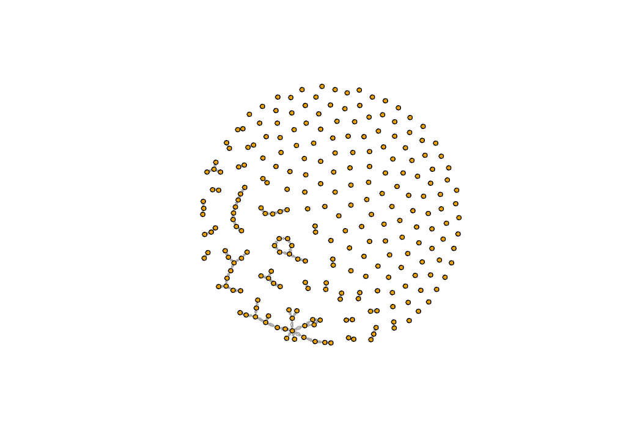

```r
#determine which edges aren't in all 3 networks
fa = difference(
        subgraph.edges(docnet2, E(docnet2)[type=="friend"]),
       subgraph.edges(docnet2, E(docnet2)[type=="advice"]))
fd = difference(
        subgraph.edges(docnet2, E(docnet2)[type=="friend"]),
        subgraph.edges(docnet2, E(docnet2)[type=="discussion"])
        )
ad = difference(
       subgraph.edges(docnet2, E(docnet2)[type=="advice"]),
       subgraph.edges(docnet2, E(docnet2)[type=="discussion"]))
af = difference(
       subgraph.edges(docnet2, E(docnet2)[type=="advice"]),
       subgraph.edges(docnet2, E(docnet2)[type=="friend"]))
da = difference(
       subgraph.edges(docnet2, E(docnet2)[type=="discussion"]),
       subgraph.edges(docnet2, E(docnet2)[type=="advice"]))
df = difference(
       subgraph.edges(docnet2, E(docnet2)[type=="discussion"]),
       subgraph.edges(docnet2, E(docnet2)[type=="friend"]))

#remove the above edges from our whole network
w1=difference(docnet2,fa)
w2=difference(w1,fd)
w3=difference(w2,ad)
w4=difference(w3,af)
w5=difference(w4,da)
w6=difference(w5,df)
#remove random network edges
w7=difference(w6, subgraph.edges(docnet2, E(docnet2)[type=="random"]) )



plot(w7,vertex.size=4, edge.arrow.size=.1,  vertex.label=NA, main="" )
```

## Community Detection

We now shall use the Newmman Eigenvector method for community detection on the whole network and see what it determines.

```r
#function implements Newman Eigenvector method
eigclust <- cluster_leading_eigen(graph=as.undirected(docnet2), steps = -1, weights = NULL, start = NULL, options = arpack_defaults, callback = NULL, extra = NULL, env = parent.frame())
```

We plot the result of the method as follows:

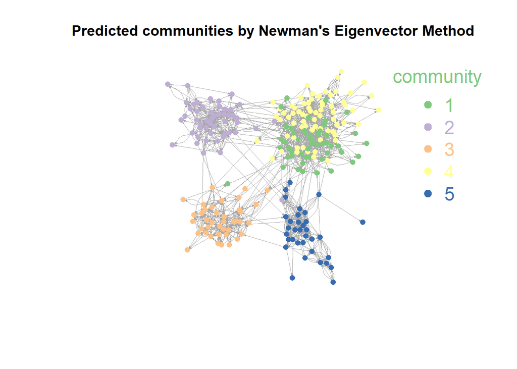

```r
doccopy <- docnet2
V(doccopy)$comm = membership(eigclust)
nclust = length(unique(membership(eigclust)))

divcols=brewer.pal(nclust, "Accent")
cols=divcols[V(doccopy)$comm]
plot(doccopy, edge.width=0.1, vertex.size=5, edge.arrow.size=0.1,vertex.label=NA,vertex.frame.color=NA,vertex.color=cols, main="Predicted communities by Newman's Eigenvector Method")

legend("topright", legend=levels(as.factor(V(doccopy)$comm))  , col = divcols , bty = "n", pch=20 , pt.cex = 2, cex = 1.5, text.col=divcols , horiz = FALSE, inset = c(0, 0), title="community")
```

We know that the doctors in our network live in four different cities. It is reasonable to assume the possibility that the doctors mostly have connections with other doctors within the same city, and our result above mirrors that fairly well.

Below is a table where the columns represent the city of the doctor and the row is the community assigned by the Newman eigenvector method.

```r
table(eigclust$membership, V(docnet2)$nodeCity)
```

```
##
##      1  2  3  4
##   1 48  0  1  0
##   2  1 48  0  1
##   3  0  0 40  0
##   4 68  0  1  0
##   5  0  0  0 34
```

Though the method used splits one city into two communities, it otherwise closely mirrors the nodeCity attribute.

We can use another clustering algorithm, walktrap, and observe how it differs from the prior method.

```r
wtclust <- cluster_walktrap(docnet2)
table(wtclust$membership, V(docnet2)$nodeCity)
```

```
##
##       1   2   3   4
##   1   0   0  38   0
##   2   0  48   0   0
##   3   0   0   0  27
##   4 112   0   1   0
##   5   0   0   0   8
##   6   0   0   3   0
##   7   5   0   0   0
```

With walktrap, there are more clusters created than with the eigenvector method, but fewer doctors are designated clusters that don’t match their city. That is, the walktrap method more accurately divides the doctors among their respective cities, but further divides three of the four cities into two intra-city clusters, perhaps unnecessarily considering how small some of the clusters are. The result of the walktrap method can be seen in the following graph:

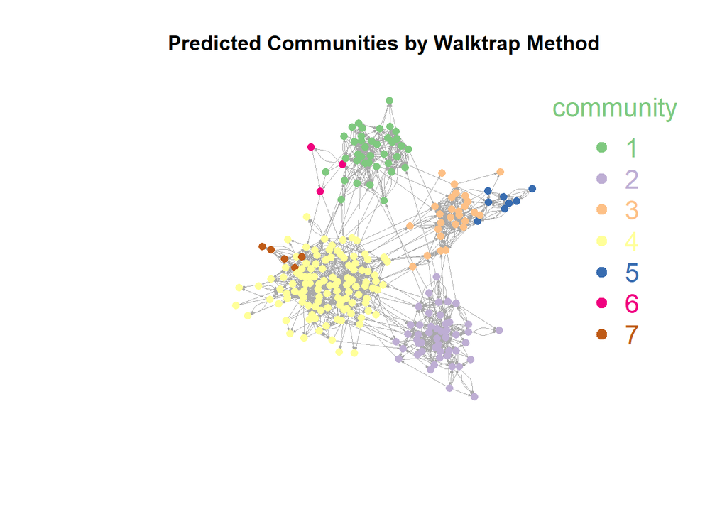

```r
doccopy <- docnet2
V(doccopy)$comm = membership(wtclust)
nclust = length(unique(membership(wtclust)))

divcols=brewer.pal(nclust, "Accent")
cols=divcols[V(doccopy)$comm]
plot(doccopy, edge.width=0.1, vertex.size=5, edge.arrow.size=0.1,vertex.label=NA,vertex.frame.color=NA,vertex.color=cols, main="Predicted Communities by Walktrap Method")

legend("topright", legend=levels(as.factor(V(doccopy)$comm))  , col = divcols , bty = "n", pch=20 , pt.cex = 2, cex = 1.5, text.col=divcols , horiz = FALSE, inset = c(0, 0), title="community")
```

## Centrality & Network Disruption

We shall now explore several measures of centrality to better understand the connections between doctors in our network. We begin by calculating centrality values for our vertices using several different algorithms:

```r
#betweeness, page_rank, closeness, alpha centrality, degree
betwcent = order(betweenness(docnet2),decreasing =TRUE )
closecent = order(closeness(as.undirected(docnet2)),decreasing=TRUE)
pgrcent = order(page_rank(docnet2)$vector, decreasing=TRUE)
alphcent = order(alpha_centrality(docnet2),decreasing=TRUE)
```

We will take the 25 most central vertices for each measure and remove them from our network and see if that seperates it into multiple components:

```r
g1 = induced.subgraph(docnet2,betwcent[25:242])
g2 = induced.subgraph(docnet2,closecent[25:242])
g3 = induced.subgraph(docnet2,pgrcent[25:242])
g4 = induced.subgraph(docnet2,alphcent[25:242])


c(components(g1)$no,
components(g2)$no,
components(g3)$no,
components(g4)$no)
```

```
## [1] 1 2 2 1
```

We shall see how this has affected the mean degree.

```r
c(mean(degree(g1)) ,
mean(degree(g2)),
mean(degree(g3)),
mean(degree(g4))
  )
```

```
## [1] 10.293578 10.798165  9.724771 12.064220
```

We shall inspect the induced subgraphs resulting from removing the 25 most central nodes under our various centrality measures:

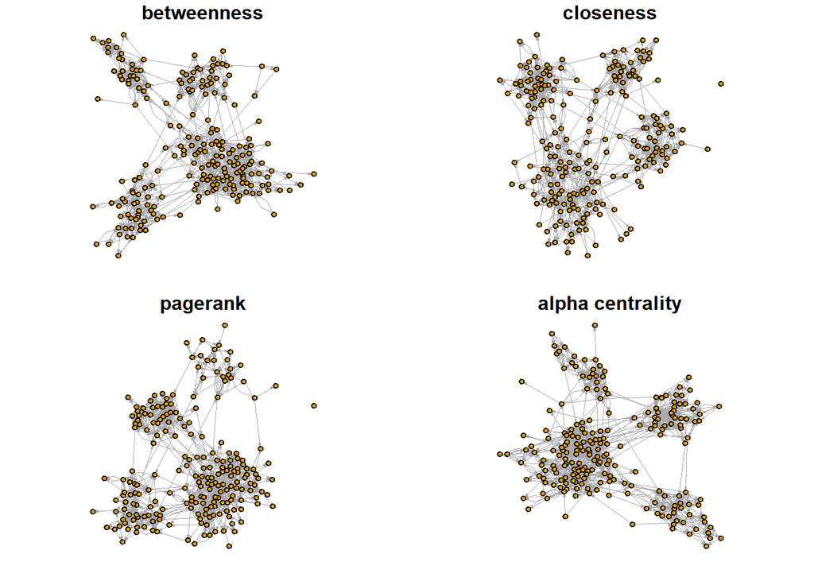

```r
par(mfrow=c(2,2), mai=c(.2,.2,.2,.2))
plot(g1, edge.width=0.1, vertex.size=5, edge.arrow.size=0.1,vertex.label=NA , main="betweenness")
plot(g2, edge.width=0.1, vertex.size=5, edge.arrow.size=0.1,vertex.label=NA , main="closeness")
plot(g3, edge.width=0.1, vertex.size=5, edge.arrow.size=0.1,vertex.label=NA ,  main= "pagerank")
plot(g4, edge.width=0.1, vertex.size=5, edge.arrow.size=0.1,vertex.label=NA ,  main= "alpha centrality")
```

With the exception of a couple isolated vertices (and our removed vertices), the networks remain connected with only the 25 most central nodes removed under our different centrality measures.

If we remove even more nodes, a further 75 to make a total of 100, we can discern the difference in performance as the number of nodes removed increases.

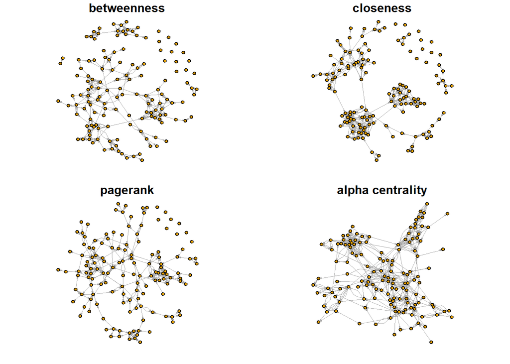

```r
g1 = induced.subgraph(docnet2,betwcent[100:242])
g2 = induced.subgraph(docnet2,closecent[100:242])
g3 = induced.subgraph(docnet2,pgrcent[100:242])
g4 = induced.subgraph(docnet2,alphcent[100:242])



par(mfrow=c(2,2), mai=c(.2,.2,.2,.2))
plot(g1, edge.width=0.1, vertex.size=5, edge.arrow.size=0.1,vertex.label=NA , main="betweenness")
plot(g2, edge.width=0.1, vertex.size=5, edge.arrow.size=0.1,vertex.label=NA , main="closeness")
plot(g3, edge.width=0.1, vertex.size=5, edge.arrow.size=0.1,vertex.label=NA ,  main= "pagerank")
plot(g4, edge.width=0.1, vertex.size=5, edge.arrow.size=0.1,vertex.label=NA ,  main= "alpha centrality")
```

If we compare this with the naive method of taking vertex degree as a measure of centrality, we find that this naive method actually marginally outperforms pagerank and alpha centrality measures when attempting to disrupt the network, though still performs poorly.

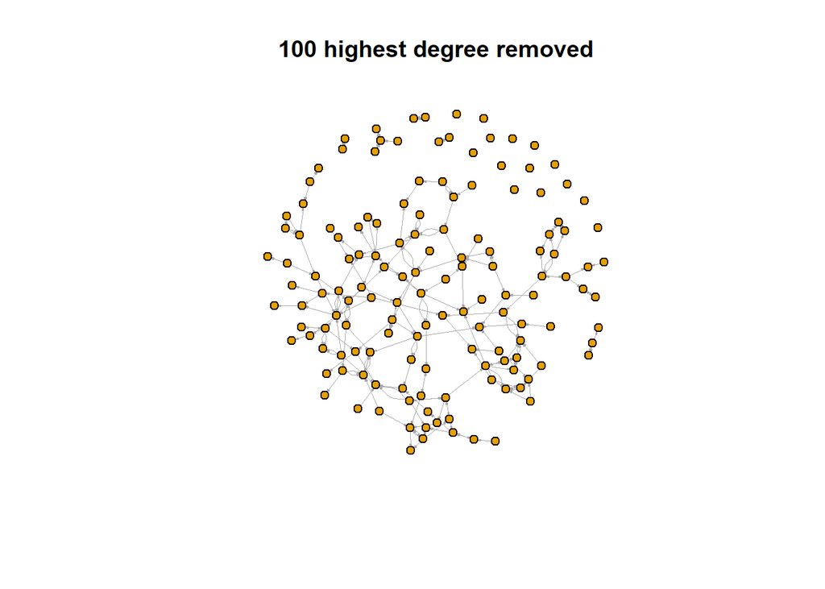

```r
degcent=order(degree(docnet2),decreasing=TRUE)
g5 = induced.subgraph(docnet2,degcent[100:242])

plot(g5, edge.width=0.1, vertex.size=5, edge.arrow.size=0.1,vertex.label=NA ,  main= "100 highest degree removed")
```

I was interested in the possibility that some combination of betweeness and closeness centrality might perform better than by themselves. The following code takes all the nodes that rank in the top 100 nodes for both closeness and betweenness. There are 70 such nodes that feature in both. The graph below is the result of removing those 70 nodes from the network. It performs worse than closeness and betweeness measures, so ignoring a higher valued node in favour of a lower valued one (in one measure) for one that performs better in the other measure, is not a favourable strategy.

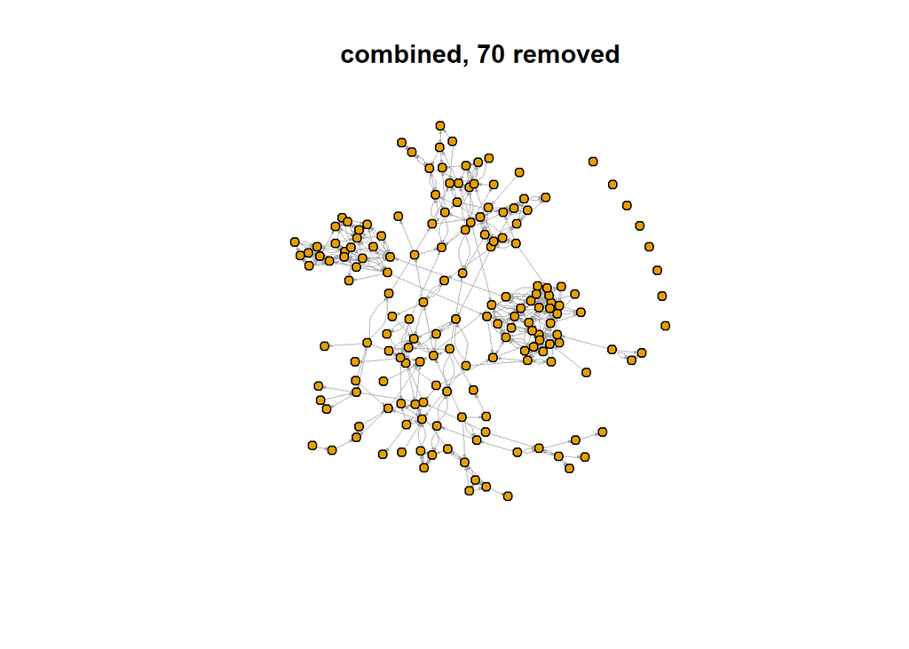

```r
#combined 20
comcent = c(betwcent[1:100]
, closecent[1:100])[duplicated(c(betwcent[1:100]
, closecent[1:100]))]

tot= c(1:242)


g6= induced.subgraph(docnet2,tot[-comcent])

plot(g6, edge.width=0.1, vertex.size=5, edge.arrow.size=0.1,vertex.label=NA ,  main= "combined, 70 removed")
```

The fact that none of these methods work well to effectively disrupt the network, even with as many as 40 percent of the total nodes removed, is indicative of the structure of the network lacking a few highly central nodes and having a fairly even distribution of connections between doctors within the same city, with a sizeable number of connections existing between those cities.

The following graph is of the network, with the size and colour of the vertices adjusted such that vertices with higher betweenness appear larger and more colourful relative to other nodes.

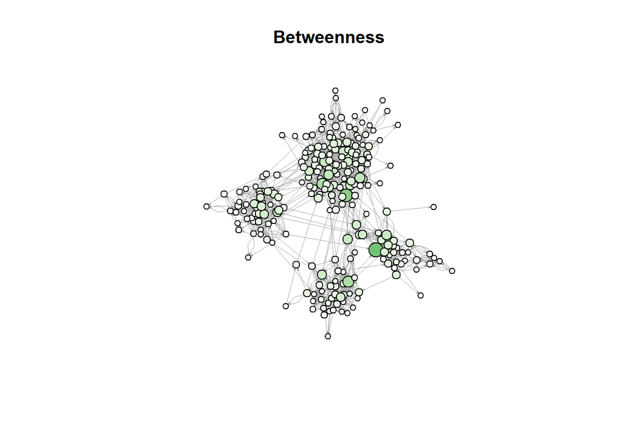

```r
NN=max(betweenness(docnet2))
myblues = colorRampPalette(brewer.pal(9,"Greens"))(NN)

Ecols=myblues[betweenness(docnet2)/2 + 50]

plot(docnet2, edge.width=0.05, vertex.size=(betweenness(docnet2)/800 + 5), vertex.color=Ecols ,edge.arrow.size=0.1,vertex.label=NA ,  main= "Betweenness")
```

## Propagation Through the Network

We shall now simulate how information would flow through our Network by modelling information as an ‘infection’ spreading through our network.

The first question we shall concern ourselves with is the effect differences in the source of the intially infected will have on the spread of infection.

The following graph shows the progression in number of infected nodes when 10 randomly selected nodes are initally infected.

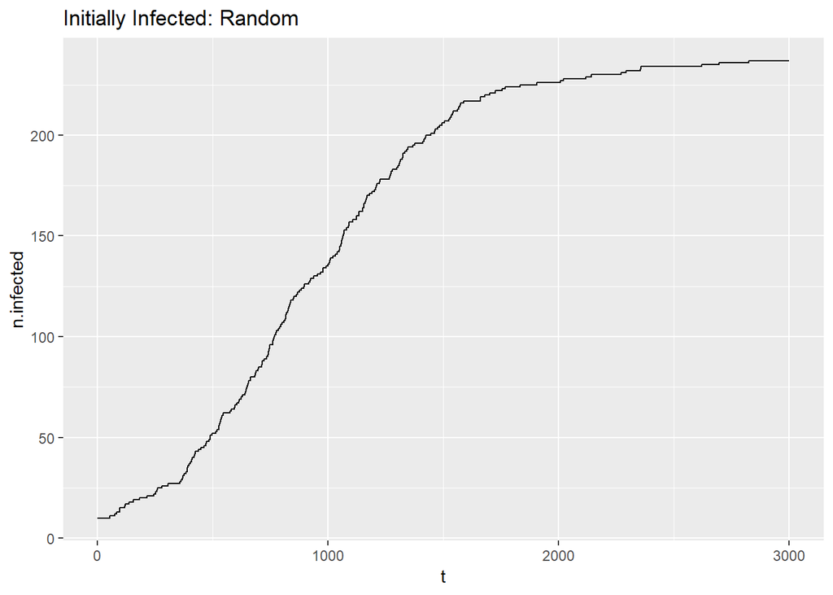

```r
mytest <- simEpi(docnet2, init_infected = sample(vcount(docnet2),10), inf.prob = 0.5, max.time = 3000)
qplot(data = mytest$numInfections, x = t, y = n.infected, geom = "line", main='Initially Infected: Random')
```

We can investigate how the infection spreads through the network when the initially infected nodes are those that are most or least central. The plots that follow compare the total number of infected nodes as time increases in 3 measures of centrality: betweenness, closeness, and degree.

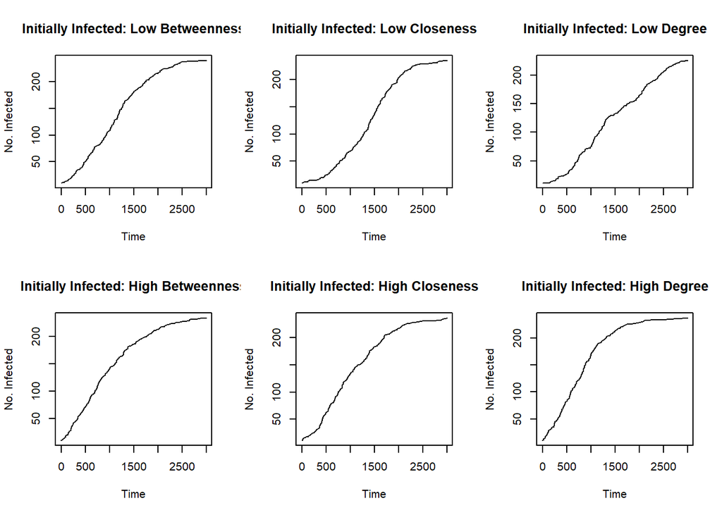

```r
mytest1 <- simEpi(docnet2, init_infected = order(betweenness(docnet2),decreasing = TRUE)[1:10], inf.prob = 0.5, max.time = 3000)
mytest2 <- simEpi(docnet2, init_infected = order(betweenness(docnet2))[1:10], inf.prob = 0.5, max.time = 3000)

mytest3 <- simEpi(docnet2, init_infected = order(closeness(as.undirected(docnet2)),decreasing = TRUE)[1:10], inf.prob = 0.5, max.time = 3000)
mytest4 <- simEpi(docnet2, init_infected = order(closeness(as.undirected(docnet2)))[1:10], inf.prob = 0.5, max.time = 3000)

mytest5<- simEpi(docnet2, init_infected = order(degree(docnet2),decreasing = TRUE)[1:10], inf.prob = 0.5, max.time = 3000)
mytest6 <- simEpi(docnet2, init_infected = order(degree(docnet2))[1:10], inf.prob = 0.5, max.time = 3000)

par(mfrow=c(2,3))

plot(mytest2$numInfections$t, mytest2$numInfections$n.infected ,type = "l", main='Initially Infected: Low Betweenness',  xlab='Time', ylab='No. Infected')
plot(mytest4$numInfections$t, mytest4$numInfections$n.infected ,type = "l", main='Initially Infected: Low Closeness', xlab='Time', ylab='No. Infected')
plot(mytest6$numInfections$t, mytest6$numInfections$n.infected ,type = "l", main='Initially Infected: Low Degree', xlab='Time', ylab='No. Infected')

plot(mytest1$numInfections$t, mytest1$numInfections$n.infected ,type = "l", main='Initially Infected: High Betweenness', xlab='Time', ylab='No. Infected')
plot(mytest3$numInfections$t, mytest3$numInfections$n.infected ,type = "l", main='Initially Infected: High Closeness', xlab='Time', ylab='No. Infected')
plot(mytest5$numInfections$t, mytest5$numInfections$n.infected ,type = "l", main='Initially Infected: High Degree', xlab='Time', ylab='No. Infected')
```

We can see that, especially in the beginning, infecting the most central nodes spreads the infection through the network much faster than targeting the least central nodes. If we wished to spread information in a network, targeting the most central nodes would ensure a faster spread of that information.

We will now investigate the effect of community membership on the spread of information.

When the initially ‘infected’ nodes are confined to one city, the ‘infection’ generally grows faster there first with growth in other cities delayed. We randomly ‘infect’ 5 nodes in one of the cities and plot the results of the spreading infection at t=1,600,1200,1800.

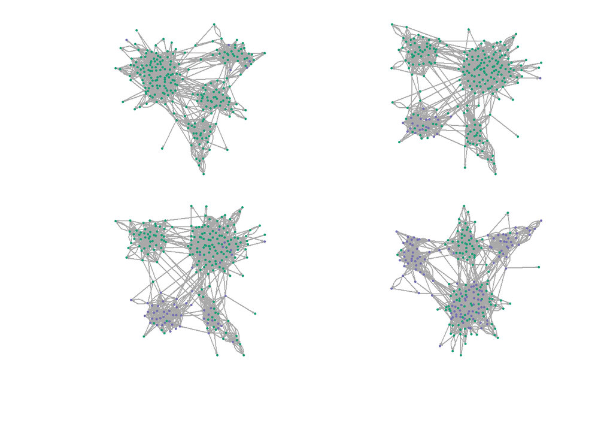

```r
mytest <- simEpi(docnet2, init_infected = sample(which(V(docnet2)$nodeCity==3),5), inf.prob = 0.5, max.time = 5000)

plotInfTimeGraph(docnet2,mytest,c(1,600,1200, 1800))
```

The following boxplot shows how long it takes to infect the nodes in different cities. Notice that city 3, the origin of our infection has the majority of its nodes infected much earlier than the other cities.

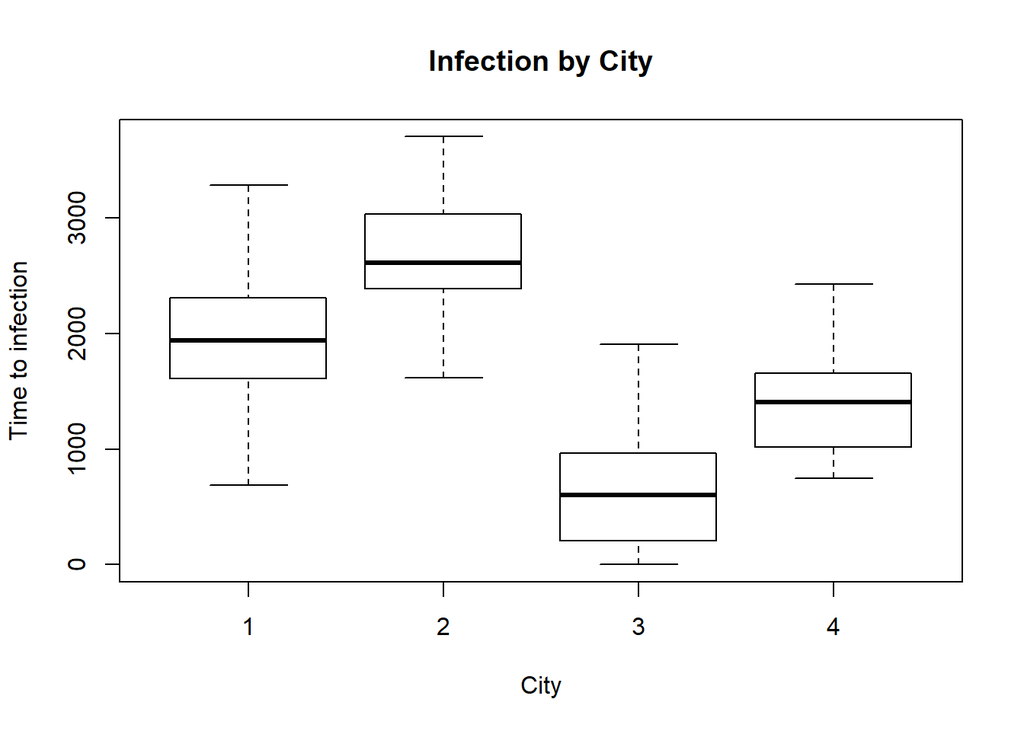

```r
boxplot(mytest$timeToInfection$time.infected~ V(docnet2)$nodeCity, xlab='City', ylab='Time to infection', outline=FALSE, main='Infection by City')
```

Lastly, we will determine whether nodes with high centrality measures are more likely to be infected earlier or later as the infection spreads, and which centrality measures result in greater disparities in this regard.

We randomly select 5 nodes to be initially infected and plot the progression of the infection through the network as follows.

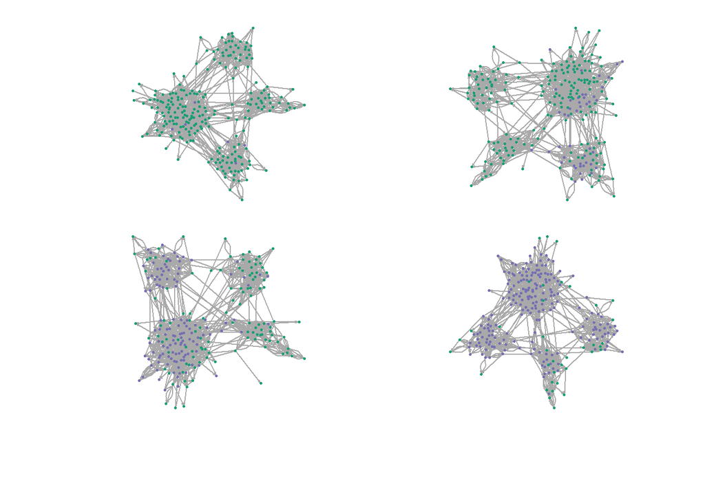

```r
mytest <- simEpi(docnet2, init_infected = sample(vcount(docnet2),5), inf.prob = 0.5, max.time = 20000)

plotInfTimeGraph(docnet2,mytest,c(1,700,1400, 2100))
```

We compare below several centrality measures against the time it took to become infected in our simulation.

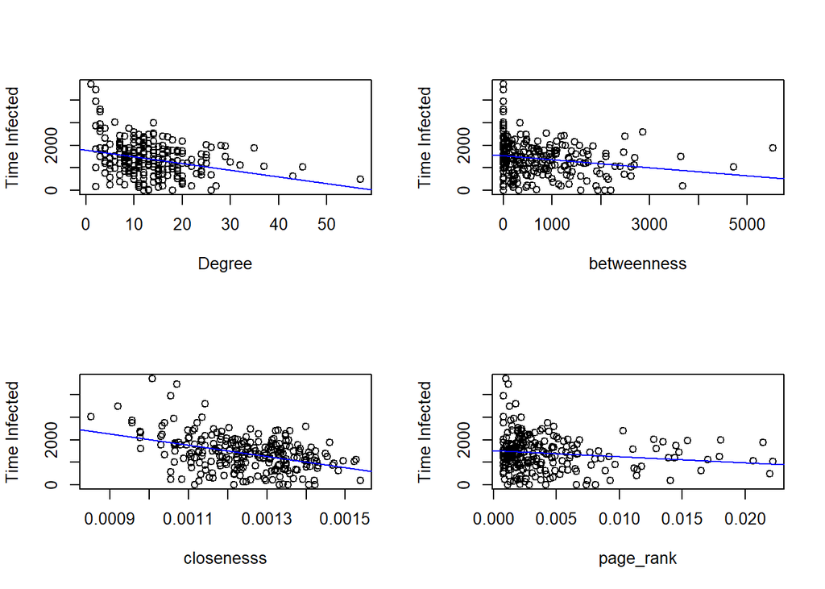

```r
par(mfrow=c(2,2))
plot( mytest$timeToInfection$Degree, mytest$timeToInfection$time.infected, xlab='Degree', ylab='Time Infected' )
abline(lm(mytest$timeToInfection$time.infected ~ mytest$timeToInfection$Degree),col="blue")
plot( betweenness(docnet2), mytest$timeToInfection$time.infected, ylab='Time Infected',xlab='betweenness')
abline(lm(mytest$timeToInfection$time.infected ~ betweenness(docnet2) ),col="blue")
plot( closeness(as.undirected(docnet2)), mytest$timeToInfection$time.infected, ylab='Time Infected',xlab='closenesss' )
abline(lm(mytest$timeToInfection$time.infected ~ closeness(as.undirected(docnet2))),col="blue")
plot( page_rank(docnet2)$vector, mytest$timeToInfection$time.infected,ylab='Time Infected',xlab='page_rank' )
abline(lm(mytest$timeToInfection$time.infected ~ page_rank(docnet2)$vector),col="blue")
```

For all of our centrality measures, an increase in centrality appears to correlate with a quicker time to infection. Combined with our earlier finding that an initial infection confined to one community will tend to spread within that community before spreading to others, we could of course expect the most central individuals in a community that is the source of an infection to become some of the first nodes infected in our network.